# Practical Examples and Use Cases

Priyanshu Tiwari

2025-12-10

## Introduction

This vignette demonstrates practical applications of the `AsianOption` package through detailed examples. All examples use verified code that has been tested to work correctly.

## Example 1: Basic Geometric Asian Option

Let’s start with a simple at-the-money geometric Asian call option:

```r
# Standard parameters
S0 <- 100      # Initial stock price
K <- 100       # At-the-money strike
r <- 1.05      # 5% risk-free rate (gross)
u <- 1.2       # 20% up move
d <- 0.8       # 20% down move
lambda <- 0.1  # Price impact coefficient
v_u <- 1       # Unit hedging volume (up)
v_d <- 1       # Unit hedging volume (down)
n <- 5         # 5 time steps

price <- price_geometric_asian(S0, K, r, u, d, lambda, v_u, v_d, n)
cat("Geometric Asian call price:", round(price, 4), "\n")
```

```
#> Geometric Asian call price: 15.8117
```

## Example 2: Impact of Price Impact Parameter

Compare prices with varying $\lambda$ to see how price impact affects option value:

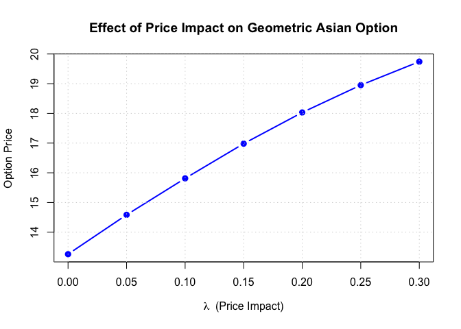

```r
lambdas <- seq(0, 0.3, by = 0.05)
prices <- sapply(lambdas, function(lam) {
  price_geometric_asian(100, 100, 1.05, 1.2, 0.8, lam, 1, 1, 5)
})

plot(lambdas, prices, type = "b",
     xlab = expression(lambda~" (Price Impact)"),
     ylab = "Option Price",
     main = "Effect of Price Impact on Geometric Asian Option",
     col = "blue", pch = 19, lwd = 2)
grid()
```

**Interpretation**: Higher price impact increases option value because hedging amplifies price movements, effectively increasing volatility.

## Example 3: Strike Price Sensitivity

Examine how option value changes with strike price:

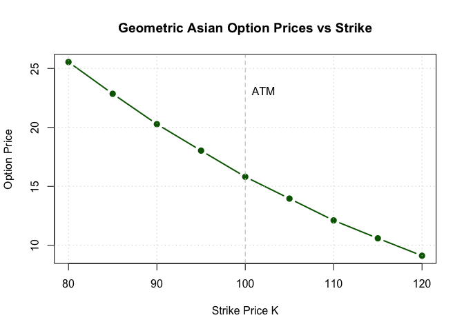

```r
strikes <- seq(80, 120, by = 5)
prices <- sapply(strikes, function(K) {
  price_geometric_asian(100, K, 1.05, 1.2, 0.8, 0.1, 1, 1, 5)
})

plot(strikes, prices, type = "b",
     xlab = "Strike Price K",
     ylab = "Option Price",
     main = "Geometric Asian Option Prices vs Strike",
     col = "darkgreen", pch = 19, lwd = 2)
abline(v = 100, lty = 2, col = "gray")
text(100, max(prices) * 0.9, "ATM", pos = 4)
grid()
```

## Example 4: Call vs Put Options

Compare call and put prices for the same parameters:

```r
# Call option
call_price <- price_geometric_asian(
  S0 = 100, K = 100, r = 1.05, u = 1.2, d = 0.8,
  lambda = 0.1, v_u = 1, v_d = 1, n = 5,
  option_type = "call"
)

# Put option
put_price <- price_geometric_asian(
  S0 = 100, K = 100, r = 1.05, u = 1.2, d = 0.8,
  lambda = 0.1, v_u = 1, v_d = 1, n = 5,
  option_type = "put"
)

cat("Call price:", round(call_price, 4), "\n")
```

```
#> Call price: 15.8117
```

```r
cat("Put price:", round(put_price, 4), "\n")
```

```
#> Put price: 9.2906
```

```r
cat("Call - Put:", round(call_price - put_price, 4), "\n")
```

```
#> Call - Put: 6.5211
```

## Example 5: Arithmetic Asian Bounds

For arithmetic Asian options, we can compute rigorous bounds:

```r
bounds <- arithmetic_asian_bounds(100, 100, 1.05, 1.2, 0.8, 0.1, 1, 1, 5)

cat("Arithmetic Asian Option Bounds:\n")
```

```
#> Arithmetic Asian Option Bounds:
```

```r
cat("  Lower (geometric price):", round(bounds$lower_bound, 4), "\n")
```

```
#>   Lower (geometric price): 15.8117
```

```r
cat("  Upper (global):", round(bounds$upper_bound_global, 4), "\n")
```

```
#>   Upper (global): 9010.344
```

```r
cat("  Midpoint estimate:", round(mean(c(bounds$lower_bound, bounds$upper_bound_global)), 4), "\n")
```

```
#>   Midpoint estimate: 4513.078
```

### Tighter Path-Specific Bounds

```r
bounds_ps <- arithmetic_asian_bounds(
  S0 = 100, K = 100, r = 1.05, u = 1.2, d = 0.8,
  lambda = 0.1, v_u = 1, v_d = 1, n = 5,
  compute_path_specific = TRUE
)

print(bounds_ps)
```

```
#> Arithmetic Asian Option Bounds
#> ================================
#> Lower bound (V0_G):        15.811668
#> Upper bound (global):      9010.343668
#> Upper bound (path-spec):   38.614313
#>   (using all 32 paths)
#> Midpoint (path-spec):      27.212990
#> Spread (rho*):             106.975455
#> E^Q[G_n]:                  108.322775
```

```r
cat("\nBound tightness:\n")
```

```
#>
#> Bound tightness:
```

```r
cat("  Global spread:", round(bounds_ps$upper_bound_global - bounds_ps$lower_bound, 2), "\n")
```

```
#>   Global spread: 8994.53
```

```r
cat("  Path-specific spread:", round(bounds_ps$upper_bound_path_specific - bounds_ps$lower_bound, 2), "\n")
```

```
#>   Path-specific spread: 22.8
```

```r
cat("  Improvement:",
    round((bounds_ps$upper_bound_global - bounds_ps$upper_bound_path_specific), 2), "\n")
```

```
#>   Improvement: 8971.73
```

**Observation**: The path-specific bound is much tighter than the global bound, providing a better estimate of the true arithmetic Asian option price.

## Example 6: Comparison With and Without Price Impact

Compare option values with and without price impact:

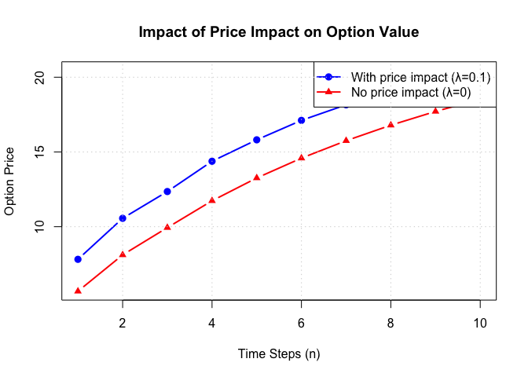

```r
n_range <- 1:10

prices_no_impact <- sapply(n_range, function(n) {
  price_geometric_asian(100, 100, 1.05, 1.2, 0.8, 0, 0, 0, n)
})

prices_with_impact <- sapply(n_range, function(n) {
  price_geometric_asian(100, 100, 1.05, 1.2, 0.8, 0.1, 1, 1, n)
})

plot(n_range, prices_with_impact, type = "b", col = "blue", pch = 19, lwd = 2,
     xlab = "Time Steps (n)", ylab = "Option Price",
     main = "Impact of Price Impact on Option Value",
     ylim = range(c(prices_no_impact, prices_with_impact)))
lines(n_range, prices_no_impact, type = "b", col = "red", pch = 17, lwd = 2)
legend("topright",
       legend = c("With price impact (λ=0.1)", "No price impact (λ=0)"),
       col = c("blue", "red"), pch = c(19, 17), lty = 1, lwd = 2)
grid()
```

## Example 7: Risk-Neutral Probability Analysis

Examine how price impact affects the risk-neutral probability:

```r
# Compute adjusted factors
factors <- compute_adjusted_factors(u = 1.2, d = 0.8, lambda = 0.1, v_u = 1, v_d = 1)
p_adj <- compute_p_adj(r = 1.05, u = 1.2, d = 0.8, lambda = 0.1, v_u = 1, v_d = 1)

# Compare with no impact
p_standard <- compute_p_adj(r = 1.05, u = 1.2, d = 0.8, lambda = 0, v_u = 0, v_d = 0)

cat("Standard CRR factors:\n")
```

```
#> Standard CRR factors:
```

```r
cat("  u =", 1.2, ", d =", 0.8, "\n")
```

```
#>   u = 1.2 , d = 0.8
```

```r
cat("  p =", round(p_standard, 4), "\n\n")
```

```
#>   p = 0.625
```

```r
cat("Adjusted factors (with impact):\n")
```

```
#> Adjusted factors (with impact):
```

```r
cat("  u_tilde =", round(factors$u_tilde, 4), "\n")
```

```
#>   u_tilde = 1.3262
```

```r
cat("  d_tilde =", round(factors$d_tilde, 4), "\n")
```

```
#>   d_tilde = 0.7239
```

```r
cat("  p_adj =", round(p_adj, 4), "\n\n")
```

```
#>   p_adj = 0.5414
```

```r
# Verify no-arbitrage
cat("No-arbitrage check:\n")
```

```
#> No-arbitrage check:
```

```r
cat("  d_tilde < r < u_tilde:",
    factors$d_tilde, "<", 1.05, "<", factors$u_tilde, "\n")
```

```
#>   d_tilde < r < u_tilde: 0.7238699 < 1.05 < 1.326205
```

```r
cat("  Valid:", check_no_arbitrage(1.05, 1.2, 0.8, 0.1, 1, 1), "\n")
```

```
#>   Valid: TRUE
```

## Example 8: Hedging Volume Sensitivity

Study the effect of different hedging volumes:

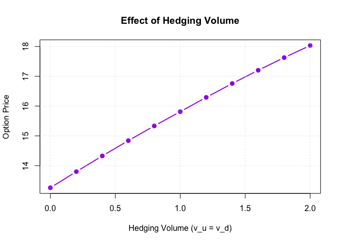

```r
v_range <- seq(0, 2, by = 0.2)

prices <- sapply(v_range, function(v) {
  price_geometric_asian(100, 100, 1.05, 1.2, 0.8, 0.1, v, v, 5)
})

plot(v_range, prices, type = "b",
     xlab = "Hedging Volume (v_u = v_d)",
     ylab = "Option Price",
     main = "Effect of Hedging Volume",
     col = "purple", pch = 19, lwd = 2)
grid()
```

## Example 9: Asymmetric Hedging Volumes

Explore the effect of asymmetric up and down hedging volumes:

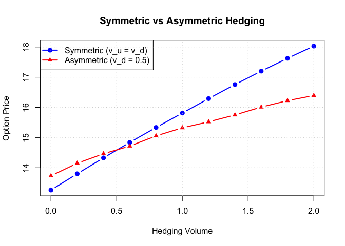

```r
v_u_vals <- seq(0, 2, by = 0.2)

# Case 1: Vary v_u, fix v_d = 0.5
prices_var_u <- sapply(v_u_vals, function(v_u) {
  price_geometric_asian(100, 100, 1.05, 1.2, 0.8, 0.1, v_u, 0.5, 5)
})

# Case 2: Symmetric volumes
prices_symmetric <- sapply(v_u_vals, function(v) {
  price_geometric_asian(100, 100, 1.05, 1.2, 0.8, 0.1, v, v, 5)
})

plot(v_u_vals, prices_symmetric, type = "b", col = "blue", pch = 19, lwd = 2,
     xlab = "Hedging Volume", ylab = "Option Price",
     main = "Symmetric vs Asymmetric Hedging",
     ylim = range(c(prices_symmetric, prices_var_u)))
lines(v_u_vals, prices_var_u, type = "b", col = "red", pch = 17, lwd = 2)
legend("topleft",
       legend = c("Symmetric (v_u = v_d)", "Asymmetric (v_d = 0.5)"),
       col = c("blue", "red"), pch = c(19, 17), lty = 1, lwd = 2)
grid()
```

## Example 10: Moneyness Analysis

Examine option prices across different levels of moneyness:

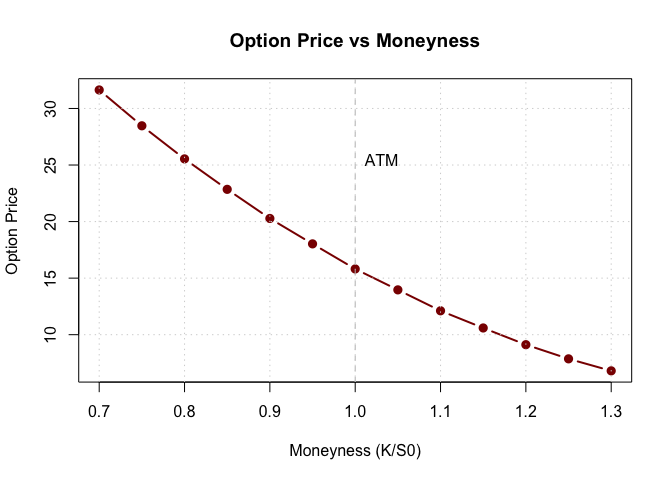

```r
# Define moneyness: K/S0
moneyness <- seq(0.7, 1.3, by = 0.05)
strikes <- moneyness * 100

prices <- sapply(strikes, function(K) {
  price_geometric_asian(100, K, 1.05, 1.2, 0.8, 0.1, 1, 1, 5)
})

plot(moneyness, prices, type = "b",
     xlab = "Moneyness (K/S0)",
     ylab = "Option Price",
     main = "Option Price vs Moneyness",
     col = "darkred", pch = 19, lwd = 2)
abline(v = 1, lty = 2, col = "gray")
text(1, max(prices) * 0.8, "ATM", pos = 4)
grid()
```